# Import Data - Exercise

Marc A.T. Teunis

2019-04-05

## Packages

[output not shown]

[output not shown]

[output not shown]

[output not shown]

**Write an Rmd file, containing code chunks (if applicable) and answer all the questions below. Store the file in a folder called: “./answers_exercises” in your course project folder. Give this file the same name as the title of the current Rmd file**

## This exercise is to learn how to load (and inspect) data in R

- Loading data into R is step 1 of every analysis
- If you can not load the data, you can not preform any analysis on it

## Selecting the proper function in {readr}

1A) What function would you use to read a file where fields were separated with  
“|”?

**ANSWER**

1B) Apart from `file`, `skip`, and `comment`, what other arguments do `readr::read_csv()` and `readr::read_tsv()` have in common?

1C) What are the most important arguments to `read_fwf()`?

1D) Sometimes strings in a CSV file contain commas. To prevent them from causing problems they need to be surrounded by a quoting character, like `"` or `'`. By convention, `read_csv()` assumes that the quoting character will be `"`, and if you want to change it you’ll need to use `read_delim()` instead. What arguments do you need to specify to read the following text into a data frame?

```
## # A tibble: 1 x 2
##       x y
##   <dbl> <chr>
## 1     1 a,b
```

1E) Identify what is wrong with each of the following inline CSV files. What happens when you run the code? Write a code chunk that corrects the code:

CSV 1

```r
read_csv("a,b\n1,2,3\n4,5,6")
```

```
## # A tibble: 2 x 2
##       a     b
##   <dbl> <dbl>
## 1     1     2
## 2     4     5
```

**ANSWER**

```
## # A tibble: 3 x 2
##       a     b
##   <dbl> <dbl>
## 1     1     2
## 2     3     4
## 3     5     6
```

CSV 2

```r
read_csv("a,b,c\n1,2\n1,2,3,4")
```

```
## # A tibble: 2 x 3
##       a     b     c
##   <dbl> <dbl> <dbl>
## 1     1     2    NA
## 2     1     2     3
```

**ANSWER**

```
## # A tibble: 2 x 3
##       a     b     c
##   <dbl> <dbl> <dbl>
## 1     1     2     3
## 2     1     2     3
```

CSV 3

```r
read_csv("a,b\n\"1")
```

```
## # A tibble: 1 x 2
##       a b
##   <dbl> <chr>
## 1     1 <NA>
```

**ANSWER**

```
## # A tibble: 1 x 2
##   a     b
##   <chr> <chr>
## 1 '1'   '2'
```

CSV 4

```r
read_csv("a,b\n1,2\na,b")
```

```
## # A tibble: 2 x 2
##   a     b
##   <chr> <chr>
## 1 1     2
## 2 a     b
```

**ANSWER**

```
## # A tibble: 1 x 2
##       a     b
##   <dbl> <dbl>
## 1     1     2
```

CSV 5

```r
read_csv("a;b\n1;3")
```

```
## # A tibble: 1 x 1
##   `a;b`
##   <chr>
## 1 1;3
```

**ANSWER**

```
## # A tibble: 1 x 2
##       a     b
##   <dbl> <dbl>
## 1     1     3
```

```
## # A tibble: 1 x 2
##       a     b
##   <dbl> <dbl>
## 1     1     3
```

## Data types

MS Excel is still a frequently used file format: `*.xls` or the “newer” format `*.xlsx`

2A) List three reasons why you should avoid MS Excel formats for your data

2B) Which functions in R (you are allowed to google) can you use to read `xls` or `xlsx` files?

2C) What does `CSV` mean?

2D) What type of delimiters (to seperate columns) can be used in datafiles? List at least 3.

**ANSWER:**

## Loading datafiles

For this exercise we are going to load and inspect a number of files

## Loading Microsoft Office Excel files.

3A) Loading an Excel file

In the `"./data"` folder of your project you wille find several example datafiles that we are going to work on during the exercises.

The first set we are going to work on is a rather simple example

“./data/Animals.xls”.

It is an Miscrosoft Excel file containing brain and body weight of a number of animals: http://mste.illinois.edu/malcz/DATA/BIOLOGY/Animals.html

DESCRIPTION: Average brain and body weights for 27 species of land animals.

VARIABLES:

- body: body weight in kg
- brain: brain weight in g

SIZE:

- Observations = 27;
- Variables = 2

SOURCE: Rousseeuw, P.J. & Leroy, A.M. (1987) Robust Regression and Outlier Detection. Wiley, p. 57.

Write a code chunk that loads the file `"./data/Animals.xls"` into R. You may use any function you like, but you are not allowed to transform the data in any way. Name the file `animals` as a datatable/dataframe/tibble in R

**TIPs**

- You can use the `readr::readxl` function to solve this question.
- Rember to use `library` to load the required package(s)
- The first row that contains data is the “Mountain Beaver” observation
- Remember that in some functions you can also set `header = FALSE`
- The variables in this dataset need to be `animal`, `body_weigth` and `brain_weigth` and IN THAT ORDER!. These are the so-called `names` of the dataframe and can be set or checked using the function `names()`
- Remember `dplyr::select`, `dplyr::filter()`, `dplyr::group_by`, `dplyr::summarize()`

**ANSWER:**

```
## * `` -> ...1
## * Weight -> Weight...2
## * Weight -> Weight...3
```

3B) Variable names. The `names` of a dataframe can be found or set with `names(dataframe)`. Try setting the names for the `animal` dataframe to `animal`, `body_weigth` and `brain_weigth` and IN THAT ORDER.

**ANSWER:**

[output not shown]

3C) Subsetting. The `animals` data can be subsetted and explored by using the subsetting functions from `dplyr`.

- Which animal has a body weight of 6654.000 kg and a brain weight of 5712.0 g?
- Write a few lines of code that extract this information from the dataframe.

**ANSWER:**

```
## # A tibble: 1 x 3
##   animal           body_weight brain_weight
##   <chr>                  <dbl>        <dbl>
## 1 African elephant        6654         5712
```

3D) Filtering. Which animal has the smallest brain weight? Write code that confirms this finding

**TIPs**

- Use `dplyr::filter()` and `%>%` to find the answer.
- You can also use `min(vector, na.rm = TRUE)` to find the answer.
- Try to write a few lines of code that answer this question with the correct output in the `Console`

```
## # A tibble: 1 x 3
##   animal body_weight brain_weight
##   <chr>        <dbl>        <dbl>
## 1 Mouse        0.023          0.4
```

```
## # A tibble: 1 x 3
##   animal body_weight brain_weight
##   <chr>        <dbl>        <dbl>
## 1 Mouse        0.023          0.4
```

3E) Plots; Create a plot that shows the realtionship between `body_weigth` and `brain_weight`. Create a dot plot, that shows this relationship.

**TIPs**

- Remember `ggplot2` from the “Visualizations” class
- Remember `geom_point()`
- Remember `geom_smooth()`
- Remember using `%>%` in conjunction with `ggplot()` and the `dplyr` verbs

#### ANSWER:

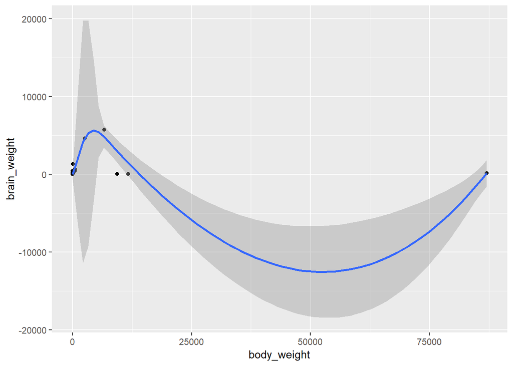

3F) Removing oulier. On the basis of the plot above, construct a new plot that eliminates the data point for the animal “Brachiosaurus”. What can you conclude from the relationship between body weigth and brain weigth, from this new plot?

**ANSWER:**

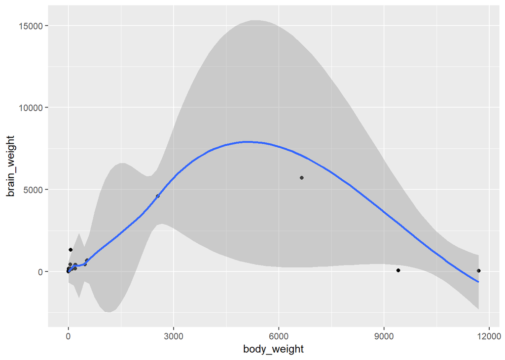

From the plot, what can you conclude about the relationship. Are there any outliers?

3G) Data Transformation. Plot the relationship of the full dataset (including “Brachiosaurus”), between body weight and brain weight. Transform the body_weight variable to a log10 scale

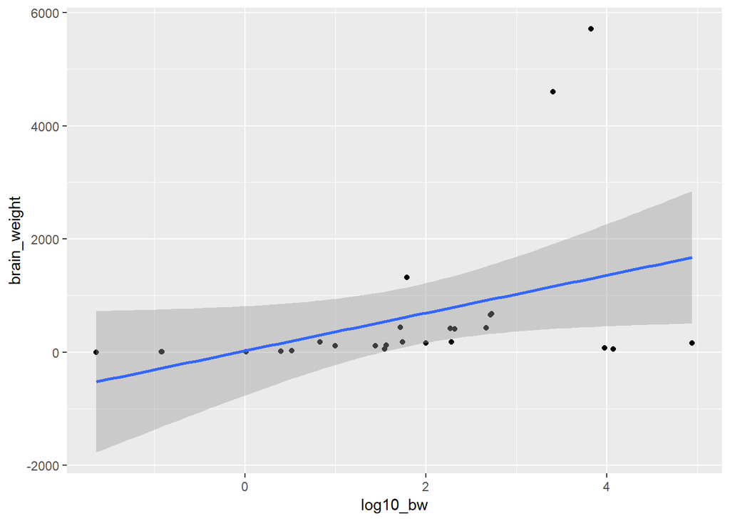

3H) What can you conclude from the 3G plot? What happens to the relation between body_weigt and brain_weight if you excluse all dinosaurs (“Brachiosaurus”, “Diplodocus” and “Triceratops”) from the dataset? **Write a short conclusion on this plot.**

**ANSWER:**

[figure not shown]

## Loading CSV files

4A Let’s load an example csv file:

Load the file:

**TIPs**

- Inspect the file first by Viewing it (left-click mouse on the file and choose “View File”).
- Remember to set the NA strings: meaning you will have to tell R what indicator in the file is used to indentify missing values: In this file “NA” and “?” are both used as ‘missing value-indices’. Construct a character vector of “NA” and “?” and use this vector as and argument to the function that loads the file.
- This datafile is a csv file, rember the `readr::read_...()` functions.

**ANSWER:**

4B) Many times data files are compressed. To uncompress a file it depends on the type of archive which function to use. Here we will try to extract the file from “.bz2” archive. This file is in “/data/storm_data_csv.bz2”. You will need the package `{R.utils}` and the function from that package `bunzip2()`. Set the `remove` option to FALSE to keep the original archive.

Extract the file and load the data into R.

**TIPS** - You should know that many times when a files is compressed it is big. How would you inspect the file to know what the delimeter is of the file, without reading the full file into R? Maybe use the Linux Terminal? - There will be some parsing error, you can ignore those for this exercise

**ANSWER:**

4C) Inspect the storm data. What types of variables are included. Think of a way to get started with a first interesting observation in a visualization.

**ANSWER**

```
##  [1] "STATE__"    "BGN_DATE"   "BGN_TIME"   "TIME_ZONE"  "COUNTY"
##  [6] "COUNTYNAME" "STATE"      "EVTYPE"     "BGN_RANGE"  "BGN_AZI"
## [11] "BGN_LOCATI" "END_DATE"   "END_TIME"   "COUNTY_END" "COUNTYENDN"
## [16] "END_RANGE"  "END_AZI"    "END_LOCATI" "LENGTH"     "WIDTH"
## [21] "F"          "MAG"        "FATALITIES" "INJURIES"   "PROPDMG"
## [26] "PROPDMGEXP" "CROPDMG"    "CROPDMGEXP" "WFO"        "STATEOFFIC"
## [31] "ZONENAMES"  "LATITUDE"   "LONGITUDE"  "LATITUDE_E" "LONGITUDE_"
## [36] "REMARKS"    "REFNUM"
```

```
## $STATE__
## [1] "double"
##
## $BGN_DATE
## [1] "character"
##
## $BGN_TIME
## [1] "character"
##
## $TIME_ZONE
## [1] "character"
##
## $COUNTY
## [1] "double"
##
## $COUNTYNAME
## [1] "character"
##
## $STATE
## [1] "character"
##
## $EVTYPE
## [1] "character"
##
## $BGN_RANGE
## [1] "double"
##
## $BGN_AZI
## [1] "logical"
##
## $BGN_LOCATI
## [1] "logical"
##
## $END_DATE
## [1] "logical"
##
## $END_TIME
## [1] "logical"
##
## $COUNTY_END
```

[output cut: 55 more lines]

```
##
## $LONGITUDE
## [1] "double"
##
## $LATITUDE_E
## [1] "double"
##
## $LONGITUDE_
## [1] "double"
##
## $REMARKS
## [1] "logical"
##
## $REFNUM
## [1] "double"
```

4D) Explore the dataset with three different visualizations. You can choose what to plot, but you will have to use `{ggplot}` to do it. Create three appealing graphs with appropriate axis labels and informative titles.

**TIPs**

- Remember ggplot’s `aes(group = ...)` and/or `aes(color = ...` and `facet_wrap()`

**ANSWER:**

4E) Which county has the most storms?

**ANSWER:**

[output not shown]

4F) Which county has the most injuries

4G) Which county has the most casualties?